# MLE Lab 2: Basic Regression and Graphs

Mateo Villamizar Chaparro

August 28, 2020

## **Important Information**:

1. **Office hours**: Tuesdays from 4:00-5:00 pm (https://duke.zoom.us/j/94327288065). We can start chatting about you small papers and replication.
2. **Labs**: Fridays from 10:15-11:30 (https://duke.zoom.us/j/93156474311)

## **Practice exercise**

Let’s see how well you can use functions in R. Construct a function called *vol* that returns the volume of a cone and a cilinder when given the radius and the height. Feel free to look at the formulas online, I’m not assuming you know these by heart, although maybe I’m wrong.

```r
vol <- function(h, r){
  cone <- round((1/3)*pi*h*r^2, 2)
  cil <- round(pi*h*r^2, 2)
  return(paste("The volume of the cone is", cone, "and the colume of the cilinder is", cil))
}

vol(1,2)
```

```
## [1] "The volume of the cone is 4.19 and the colume of the cilinder is 12.57"
```

## **The Basic Linear Model**

Let’s derive the OLS result using matrices and then using that information to manually calculate the ressults of a simple regression. In matrix terms we could have a linear model like this
$$\begin{bmatrix} y_1 \\ y_2 \\ \vdots \\y_n\end{bmatrix}_{nx1} = \begin{bmatrix} 1 & x_{11} & x_{12} & \cdots & x_{1k} \\ 1 & x_{21} & x_{22} & \cdots & x_{2k} \\ \vdots & \vdots & \vdots & \ddots & \vdots \\ 1 & x_{n1} & x_{n2} & \cdots & x_{nk}\end{bmatrix}_{nxk} \begin{bmatrix} \beta_1 \\ \beta_2 \\ \vdots \\ \beta_n \end{bmatrix}_{kx1} + \begin{bmatrix} \epsilon_1 \\ \epsilon_2 \\ \vdots \\ \epsilon_n\end{bmatrix}_{nx1}$$
For ease of notation, we will use capital letters to indicate matrices. Have an extra look to the size of the matrices and make sure they are comformable. The goal of this is obtain a formula for the residuals

$$\begin{split}
Y &= X\beta+\epsilon \\
\\
\epsilon &= Y - X \hat\beta
\end{split}$$
For OLS, we would want to minimize the sum of the squared residuals (SSR) $\epsilon' \epsilon$. In this case $\epsilon$ is a vector and $\epsilon' \epsilon = \sum_{i=1}^n e^2_i$. But, don’t trust me, let’s see why this is the case and start recalling some matrix algebra.

$$\begin{split}
SSR &= \epsilon'\epsilon \\
&= \begin{bmatrix} \epsilon_1 & \cdots & \epsilon_n \end{bmatrix} \begin{bmatrix} \epsilon_1 \\ \vdots \\ \epsilon_n \end{bmatrix} \\
\\
&= \begin{bmatrix} \epsilon_1*\epsilon_1 + \epsilon_2*\epsilon_2 + \cdots + \epsilon_n*\epsilon_n \end{bmatrix} \\
\\
&= \sum_{i=1}^n \epsilon^2_i
\end{split}$$
**Is the resulting SSR a scalar, a vector or a matrix?**

Let’s continue the derivation:

$$\begin{split}
\epsilon'*\epsilon &= (Y-X\hat\beta)'(Y-X\hat\beta) \\
\\
&= (Y' - X'\hat\beta')(Y-X\hat\beta) \\
\\
&=Y'Y - \beta'X'Y - Y'X\beta + \hat\beta'X'X'\hat\beta \\
\\
& = Y'Y - 2\hat\beta'XY + \hat\beta'X'X'\hat\beta
\end{split}$$
Here we are using the fact that the *transpose of a scalar is the same scalar*. Why? Let’s check the sizes of the matrices.

With this result, since we want to minimize the SSR, then we just partially derive the equation with respect to $\hat\beta$ and equalize the result to zero.

$$\begin{split}
\frac{\partial SSR}{\partial \hat\beta} = -2X'Y + 2 X'X\hat\beta &= 0 \\
\\
2 X'X'\hat\beta &= 2X'Y \\
\\
X'X\hat\beta &= X'Y \\
\\
(X'X)^{-1} X'X \hat\beta &= (X'X)^{-1}X'Y \\
\\
I\hat\beta &= (X'X)^{-1}X'Y \\
\\
\hat\beta &= (X'X)^{-1}X'Y
\end{split}$$
To understand the derivative of the second term refer to Green 2007, pages 981-982. But basically, $x'Ax=\sum_{i=1}^n\sum_{j=i}^n x_ix_j*a_{ij}$ which follows a quadratic form then $\frac{\partial Y}{\partial x}=2Ax$. There are some mathematical properties from the $(X'X)$ matrix that allow $(X'X)^{-1}$ to exist: it is symmetric, it is a square matrix and is positive definite matrix (it basically works the same as a real number). See additional resources if you’re interested in the algebra behind this.

### Let’s use R to calculate this manually

We are going to use the PhD publications dataset in the [AER package](https://cran.r-project.org/web/packages/AER/AER.pdf). This dataset has information on the scientific productivity of PhD students in biochemistry. It has 6 variables and we are interested in learning what are the factors that influence the productivity of PhD students.

```
## Factors are dropped from the summary
```

|  | N |  | Mean | SD |  | Min | Q1 | Median | Q3 | Max |
| --- | --- | --- | --- | --- | --- | --- | --- | --- | --- | --- |
| articles | 915 |  | 1.69 | 1.93 |  | 0.00 | 0.00 | 1.00 | 2.00 | 19.00 |
| kids | 915 |  | 0.50 | 0.76 |  | 0.00 | 0.00 | 0.00 | 1.00 | 3.00 |
| prestige | 915 |  | 3.10 | 0.98 |  | 0.75 | 2.26 | 3.15 | 3.92 | 4.62 |
| mentor | 915 |  | 8.77 | 9.48 |  | 0.00 | 3.00 | 6.00 | 12.00 | 77.00 |
| female | 915 |  | 0.46 | 0.50 |  | 0.00 | 0.00 | 0.00 | 1.00 | 1.00 |
| not_marr | 915 |  | 0.34 | 0.47 |  | 0.00 | 0.00 | 0.00 | 1.00 | 1.00 |

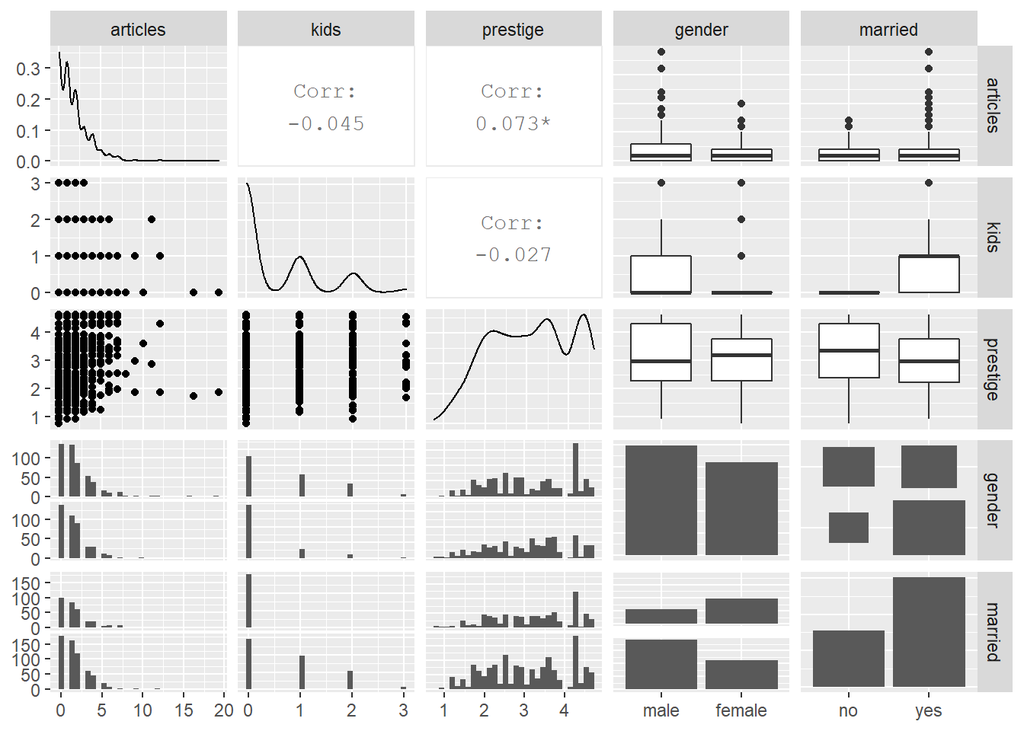

After analyzing the data, let’s run our regression

```r
# Create our outcome variable
Y <- Df1$articles

# Create our covariates matrix, whenever you create your matrix by hand remember to include the intercept! Again, there are multiple ways of doing this. Choose the one you feel more comfortable
X <- cbind(1, as.matrix(Df1[c(-1, -2, -3)]))  # The advantage of this one is that we keep the column names, but with big datasets is harder
X <- cbind(1, Df1$kids, Df1$prestige, Df1$mentor, Df1$female, Df1$not_marr) # This ones gives us a matrix directly
colnames(X) <- c("intercept", "kids", "prestige", "mentor", "female", "not married")

# Time to calculate the betas
Betas <- solve(t(X)%*%X)%*%t(X)%*%Y           # Notice here that when you are multiplying matrices you need to use %*%, also when taking the inverse of a matrix ALWAYS use the command solve NOT ^-1.

mod1 <- lm(articles ~ kids + prestige + mentor + female + not_marr, data = Df1)

# Let's compare them side by side
CompBetas <- cbind(Betas, mod1$coefficients)
colnames(CompBetas) <- c("Manual", "lm function")
round(CompBetas, 3)
```

```
##             Manual lm function
## intercept    1.597       1.597
## kids        -0.291      -0.291
## prestige    -0.011      -0.011
## mentor       0.061       0.061
## female      -0.381      -0.381
## not married -0.263      -0.263
```

### Let’s practice some OLS interpretations and make some graphs

Let’s go back a bit and run different models to remember the interpretation of coefficients

1. Let’s look at a regression between articles and gender.

```r
# Regression with one Dummy
OLS2 <- lm(articles ~ female, data = Df1)
OLS2 <- lm(articles ~ gender, data = Df1) #Notice that we can use factor variables as well
summary(OLS2)
```

```
##
## Call:
## lm(formula = articles ~ gender, data = Df1)
##
## Residuals:
##     Min      1Q  Median      3Q     Max
## -1.8826 -1.4703 -0.4703  0.5297 17.1174
##
## Coefficients:
##              Estimate Std. Error t value Pr(>|t|)
## (Intercept)   1.88259    0.08621  21.837  < 2e-16 ***
## genderfemale -0.41228    0.12709  -3.244  0.00122 **
## ---
## Signif. codes:  0 '***' 0.001 '**' 0.01 '*' 0.05 '.' 0.1 ' ' 1
##
## Residual standard error: 1.916 on 913 degrees of freedom
## Multiple R-squared:  0.01139,    Adjusted R-squared:  0.01031
## F-statistic: 10.52 on 1 and 913 DF,  p-value: 0.001222
```

```r
# Regression with a continous variable
OLS3 <- lm(articles ~ mentor, data = Df1)
summary(OLS3)
```

```
##
## Call:
## lm(formula = articles ~ mentor, data = Df1)
##
## Residuals:
##     Min      1Q  Median      3Q     Max
## -4.9313 -1.2695 -0.3968  0.6684 15.2428
##
## Coefficients:
##             Estimate Std. Error t value Pr(>|t|)
## (Intercept) 1.148305   0.082623  13.898   <2e-16 ***
## mentor      0.062117   0.006399   9.707   <2e-16 ***
## ---
## Signif. codes:  0 '***' 0.001 '**' 0.01 '*' 0.05 '.' 0.1 ' ' 1
##
## Residual standard error: 1.835 on 913 degrees of freedom
## Multiple R-squared:  0.09355,    Adjusted R-squared:  0.09256
## F-statistic: 94.23 on 1 and 913 DF,  p-value: < 2.2e-16
```

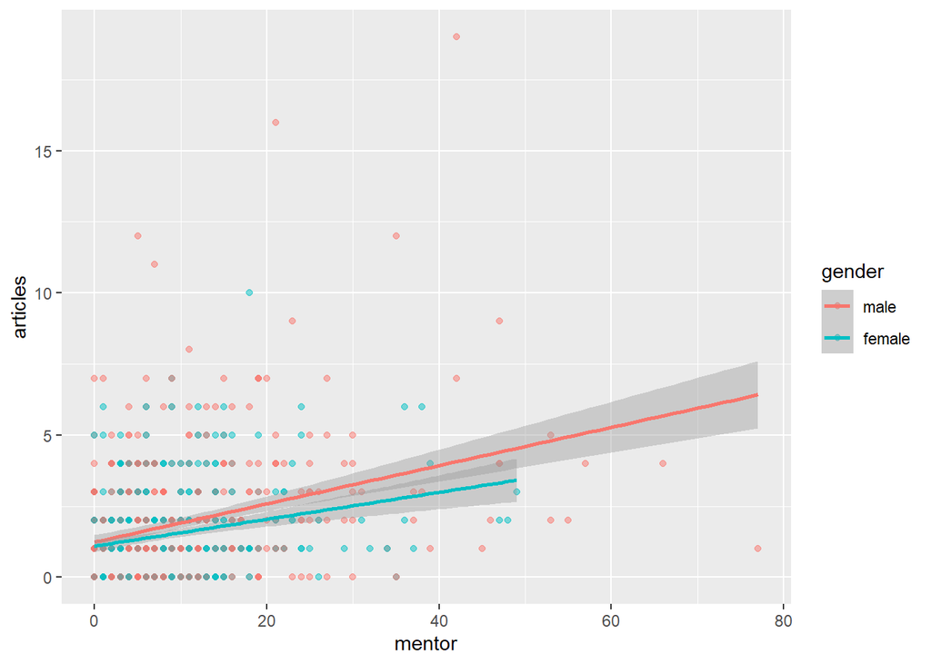

```r
# Let's create a scatter plot and see if there are any differences across genders
ggplot(Df1, aes(x=mentor, y=articles, color = gender)) +
  geom_point(alpha=0.5) + geom_smooth(method = lm) # Notice that here I'm calling the factor variable gender instead of the dummy variable female
```

```r
# regression with an interaction
OLS4 <- lm(articles ~ mentor * female, data = Df1)
summary(OLS4)
```

```
##
## Call:
## lm(formula = articles ~ mentor * female, data = Df1)
##
## Residuals:
##     Min      1Q  Median      3Q     Max
## -5.4198 -1.2415 -0.3819  0.7127 14.9340
##
## Coefficients:
##                Estimate Std. Error t value Pr(>|t|)
## (Intercept)    1.241536   0.110957  11.189   <2e-16 ***
## mentor         0.067250   0.007813   8.608   <2e-16 ***
## female        -0.143367   0.167220  -0.857    0.391
## mentor:female -0.019961   0.013623  -1.465    0.143
## ---
## Signif. codes:  0 '***' 0.001 '**' 0.01 '*' 0.05 '.' 0.1 ' ' 1
##
## Residual standard error: 1.828 on 911 degrees of freedom
## Multiple R-squared:  0.1021, Adjusted R-squared:  0.09916
## F-statistic: 34.54 on 3 and 911 DF,  p-value: < 2.2e-16
```

Here it is important to remember two things:

- How to calculate the marginal effects
  - $\hat\beta_0$ : male and the mentor no publications
  - $\hat\beta_1$ : one additional mentor article in the number of pu art for males
  - $\hat\beta_2$ : the effect of being female with a mentor with zero published articles
  - Effect of being female : $\beta_2 + \beta_3 \times mentor$
  - Effect of one more article written by the mentor : $\beta_1 + \beta_3 * female$
- Notice that to include all parent and interaction terms we used * but you can also
  - Include just the interaction term by using x1:x2
  - Nest the second variable in the first by using X1/x2 which could be useful shortcut for [calculating marginal effects](https://grantmcdermott.com/2019/12/16/interaction-effects/)
  - Include all parent and interaction terms x1*x2
2. Let’s go back to the full regression now

```r
# Full regression
# some visual representation of the coefficients using the broom package and ggplot
TidyOLS <- tidy(mod1, conf.int = T) # creates a new element that makes graphing easier
TidyOLS
```

```
## # A tibble: 6 x 7
##   term        estimate std.error statistic  p.value conf.low conf.high
##   <chr>          <dbl>     <dbl>     <dbl>    <dbl>    <dbl>     <dbl>
## 1 (Intercept)   1.60     0.223       7.17  1.54e-12   1.16      2.03
## 2 kids         -0.291    0.0909     -3.21  1.40e- 3  -0.470    -0.113
## 3 prestige     -0.0114   0.0637     -0.179 8.58e- 1  -0.136     0.114
## 4 mentor        0.0615   0.00661     9.31  9.34e-20   0.0485    0.0745
## 5 female       -0.381    0.128      -2.97  3.03e- 3  -0.632    -0.129
## 6 not_marr     -0.263    0.145      -1.81  7.06e- 2  -0.549     0.0222
```

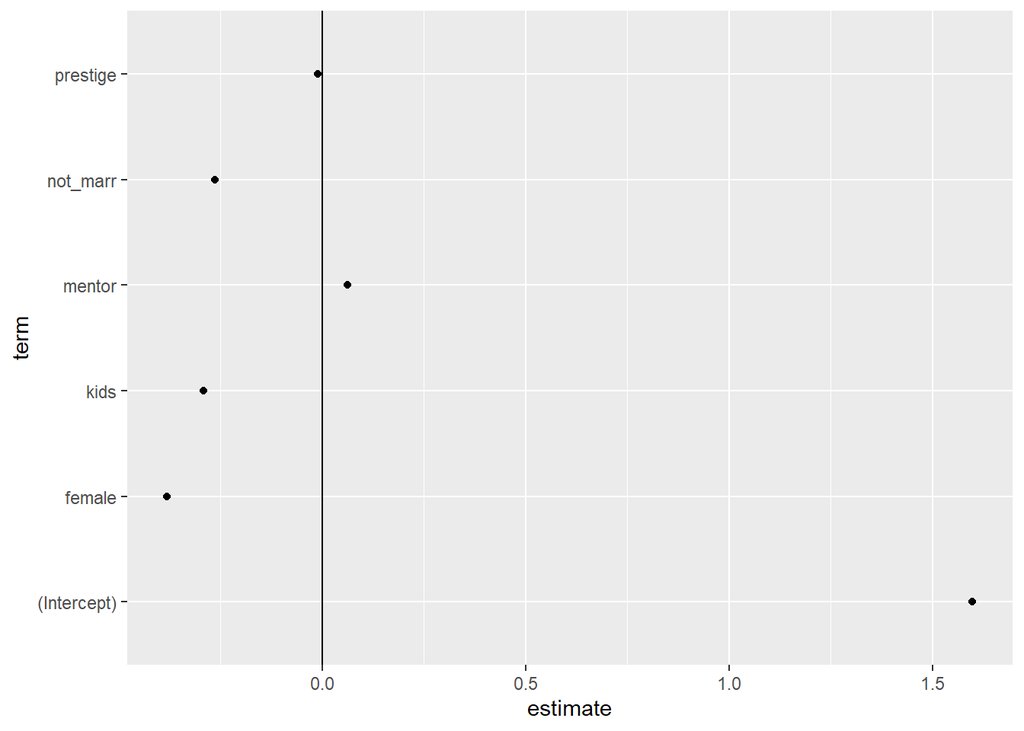

```r
# Let's graph a coefficient plot
P1 <- ggplot(TidyOLS, mapping = aes(x=term, y=estimate)) + geom_point() # creates a coefficient plot
P1 + geom_hline(yintercept = 0) + coord_flip()                          # includes the vertical line in zero and flips coordinates
```

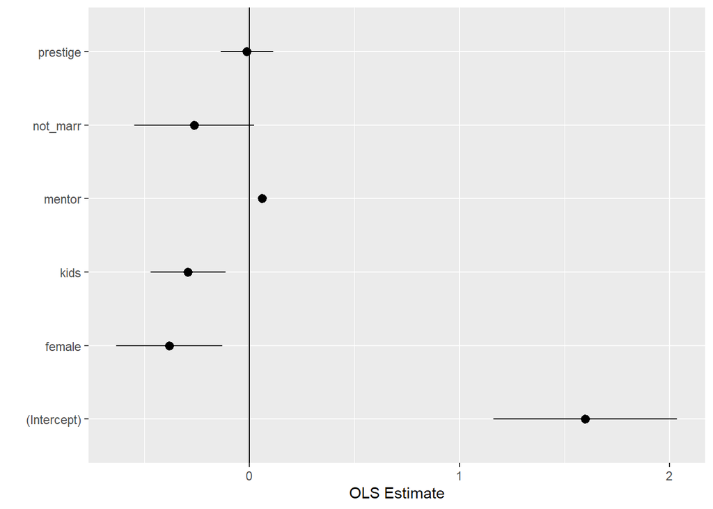

```r
# Let's add the standard errors
p <- ggplot(TidyOLS, mapping = aes(x = term, y = estimate, ymin = conf.low, ymax = conf.high))
p + geom_pointrange() + coord_flip() + labs(x="", y="OLS Estimate") + geom_hline(yintercept = 0)
```

### Some good practices when running regressions

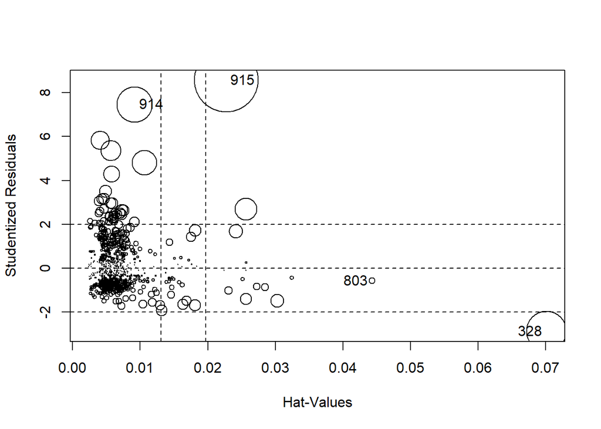

```
##        StudRes         Hat       CookD
## 328 -2.8695450 0.070106248 0.102649199
## 803 -0.5734487 0.044304979 0.002542681
## 914  7.4558039 0.009187181 0.081040181
## 915  8.5625823 0.022720548 0.263155530
```

```r
# Check for influential observations and outliers that could be driving the model
influencePlot(mod1)
```

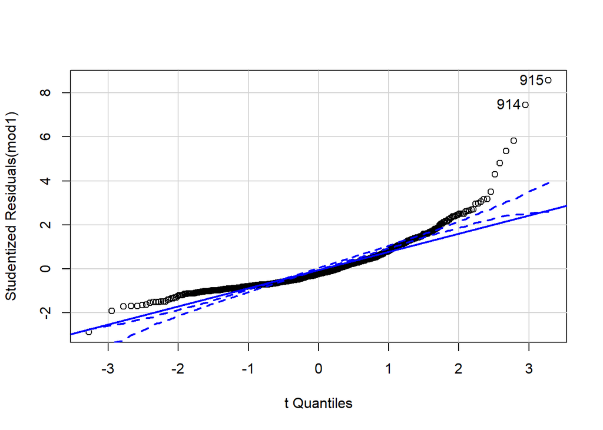

```
## [1] 914 915
```

```r
# Check distribution assumptions, here we would like to see a line that implies our data came from a given distributon, in this case a normal one
qqPlot(mod1)
```

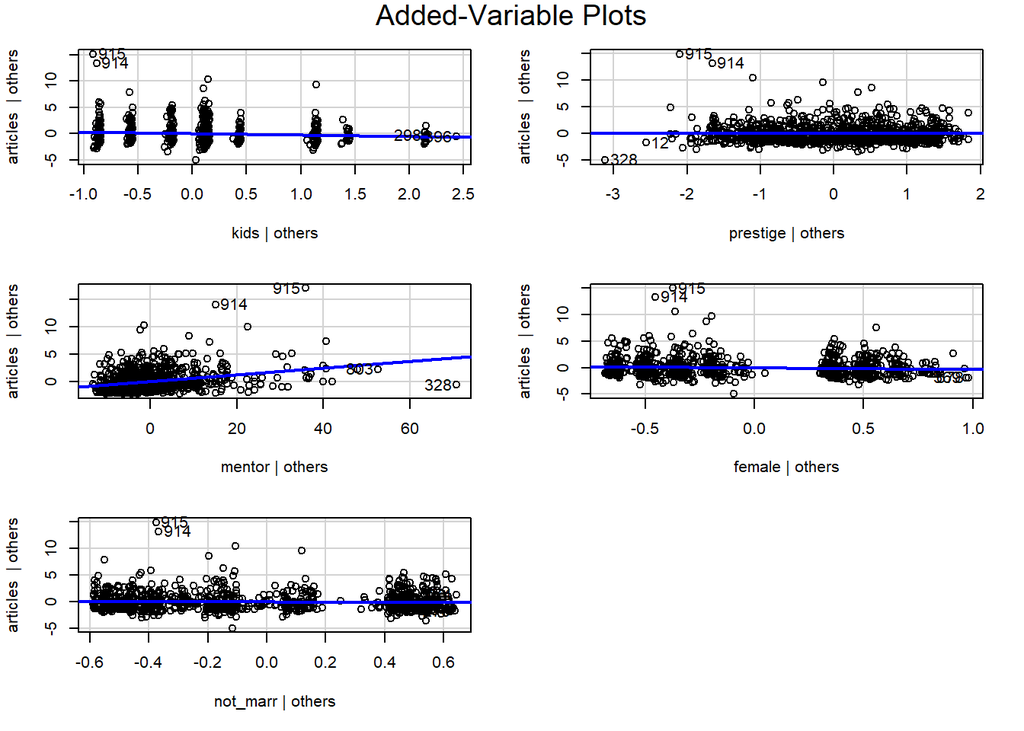

```r
# Check for influential variables in the model
avPlots(mod1)
```

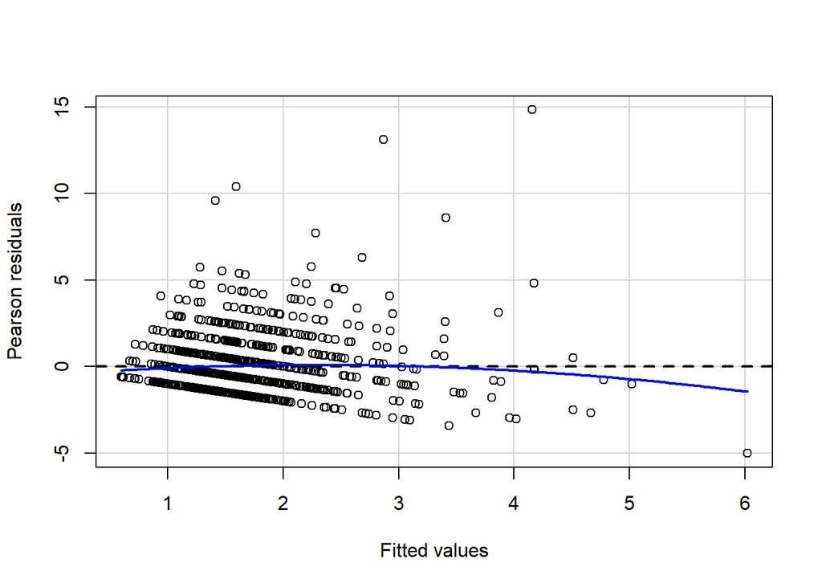

```
##            Test stat Pr(>|Test stat|)
## Tukey test   -1.7424          0.08144 .
## ---
## Signif. codes:  0 '***' 0.001 '**' 0.01 '*' 0.05 '.' 0.1 ' ' 1
```

```r
# Check to see if the assumptions of linearity and homoskedasticity apply
# We would like to find a horizontal line and a sort of "cloud" pattern, any deviations from that might indicate the model has some issues
residualPlots(mod1, ~1)  # To calculate the residual versus fitted values plot
```

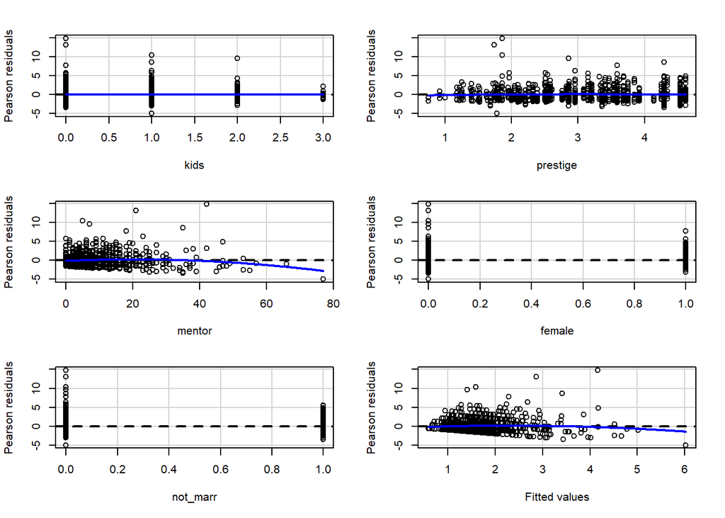

```
##            Test stat Pr(>|Test stat|)
## kids         -0.2892         0.772473
## prestige     -0.9033         0.366607
## mentor       -3.0632         0.002255 **
## female       -1.3037         0.192666
## not_marr      0.0159         0.987283
## Tukey test   -1.7424         0.081440 .
## ---
## Signif. codes:  0 '***' 0.001 '**' 0.01 '*' 0.05 '.' 0.1 ' ' 1
```

```r
residualPlots(mod1)      # Shows the residual plots for all variables and the fitted values
```